# Decades of Houston Heat: A Seasonal Analysis of Daily High Temperatures

Author

Oluchi Nnadi

Published

June 23, 2026

## Introduction

This document analyzes three decades of daily high temperatures in Houston, Texas, spanning from January 1, 1996, to December 31, 2025. The data is retrieved from the **Open-Meteo Historical Weather API**, which compiles high-resolution meteorological reanalysis data.

Houston is known for its humid subtropical climate (Köppen classification *Cfa*), characterized by hot, humid summers and mild winters. This analysis visualizes the daily maximum temperatures, highlights seasonal patterns, and explores the meteorological reasons behind temperature variability and extreme weather events.

## Data & Visualization Script

The following R code fetches the 30-year dataset (caching it locally as a JSON file for quick re-rendering) and produces an interactive scatter plot with a seasonal trendline and annotations for major climatic features.

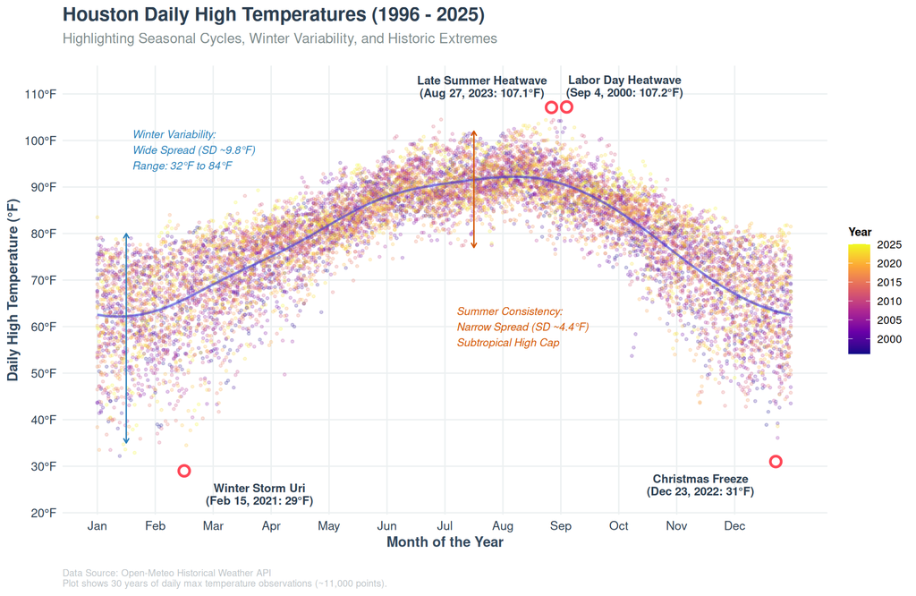

```r
library(jsonlite)
library(dplyr)
library(lubridate)
library(ggplot2)

# 1. Load Data
# We use a cached local file if it exists, otherwise we fetch from the API.
json_file <- "houston_temp.json"
if (file.exists(json_file)) {
  raw_data <- fromJSON(json_file)
} else {
  url <- "http://archive-api.open-meteo.com/v1/archive?latitude=29.7633&longitude=-95.3633&start_date=1996-01-01&end_date=2025-12-31&daily=temperature_2m_max&temperature_unit=fahrenheit&timezone=America%2FChicago"
  raw_data <- fromJSON(url)
}

# Convert daily data list to a clean data frame
data <- raw_data$daily |>
  as.data.frame() |>
  mutate(
    date = as.Date(time),
    year = year(date),
    month_num = month(date),
    day = day(date),
    temp = temperature_2m_max,
    # Compute a continuous month position (e.g., January 1st is 1.0, December 31st is ~12.97)
    # This allows points to flow smoothly across the x-axis rather than clustering in vertical columns
    decimal_month = month_num + (day - 1) / days_in_month(date)
  ) |>
  filter(!is.na(temp))

# 2. Define Historic Weather Highlights
extremes <- data.frame(
  date = as.Date(c("2021-02-15", "2000-09-04", "2023-08-27", "2022-12-23")),
  temp = c(29.0, 107.2, 107.1, 31.0),
  label = c(
    "Winter Storm Uri\n(Feb 15, 2021: 29°F)",
    "Labor Day Heatwave\n(Sep 4, 2000: 107.2°F)",
    "Late Summer Heatwave\n(Aug 27, 2023: 107.1°F)",
    "Christmas Freeze\n(Dec 23, 2022: 31°F)"
  ),
  decimal_month = c(
    2 + (15 - 1) / 28,
    9 + (4 - 1) / 30,
    8 + (27 - 1) / 31,
    12 + (23 - 1) / 31
  ),
  nudge_x = c(1.3, 1, -1.2, -1.3),
  nudge_y = c(-5, 4.5, 4.5, -5)
)

# 3. Create the Scatter Plot
ggplot(data, aes(x = decimal_month, y = temp)) +
  # Continuous scatter of daily high temps colored by year (older to newer)
  geom_point(aes(color = year), alpha = 0.2, size = 0.8) +
  # Plasma palette provides beautiful contrast and clearly depicts the timeline
  scale_color_viridis_c(option = "plasma", name = "Year") +

  # Trendline: Generalized Additive Model (GAM) with a cyclic cubic spline
  # This enforces a smooth, natural transition from December back into January
  geom_smooth(aes(group = 1), method = "gam", formula = y ~ s(x, bs = "cc"),
              color = "#4821d688", linewidth = 0.8, se = TRUE, fill = "#00d2d3", alpha = 0.15) +

  # Add circles around extreme highlight points
  geom_point(data = extremes, aes(x = decimal_month, y = temp),
             color = "#ff4757", size = 3, shape = 21, stroke = 1.5, fill = "white") +

  # Add text labels for extreme highlights
  geom_text(data = extremes, aes(x = decimal_month, y = temp, label = label),
            nudge_x = extremes$nudge_x, nudge_y = extremes$nudge_y,
            size = 3.2, fontface = "bold", color = "#2c3e50", lineheight = 0.9) +

  # Draw arrows highlighting monthly variability ranges
  # Winter range arrow
  annotate("segment", x = 1.5, xend = 1.5, y = 35, yend = 80,
           color = "#2980b9", linewidth = 0.5, arrow = arrow(length = unit(0.15, "cm"), ends = "both")) +
  annotate("text", x = 1.6, y = 98, label = "Winter Variability:\nWide Spread (SD ~9.8°F)\nRange: 32°F to 84°F",
           size = 3, color = "#2980b9", fontface = "italic", hjust = 0) +

  # Summer range arrow
  annotate("segment", x = 7.5, xend = 7.5, y = 77, yend = 102,
           color = "#d35400", linewidth = 0.5, arrow = arrow(length = unit(0.15, "cm"), ends = "both")) +
  annotate("text", x = 7.2, y = 60, label = "Summer Consistency:\nNarrow Spread (SD ~4.4°F)\nSubtropical High Cap",
           size = 3, color = "#d35400", fontface = "italic", hjust = 0) +

  # Scales & Labels Formatting
  scale_x_continuous(
    breaks = 1:12,
    labels = c("Jan", "Feb", "Mar", "Apr", "May", "Jun", "Jul", "Aug", "Sep", "Oct", "Nov", "Dec"),
    limits = c(1, 13)
  ) +
  scale_y_continuous(
    breaks = seq(20, 110, 10),
    labels = paste0(seq(20, 110, 10), "°F")
  ) +
  labs(
    title = "Houston Daily High Temperatures (1996 - 2025)",
    subtitle = "Highlighting Seasonal Cycles, Winter Variability, and Historic Extremes",
    x = "Month of the Year",
    y = "Daily High Temperature (°F)",
    caption = "Data Source: Open-Meteo Historical Weather API\nPlot shows 30 years of daily max temperature observations (~11,000 points)."
  ) +
  theme_minimal(base_family = "sans") +
  theme(
    plot.title = element_text(face = "bold", size = 15, color = "#2c3e50", margin = margin(b = 6)),
    plot.subtitle = element_text(size = 11, color = "#7f8c8d", margin = margin(b = 15)),
    axis.title = element_text(face = "bold", size = 11, color = "#34495e"),
    axis.text = element_text(size = 9.5, color = "#2c3e50"),
    panel.grid.minor = element_blank(),
    panel.grid.major.x = element_line(color = "#ecf0f1", linewidth = 0.5),
    panel.grid.major.y = element_line(color = "#ecf0f1", linewidth = 0.5),
    legend.position = "right",
    legend.title = element_text(face = "bold", size = 9),
    legend.text = element_text(size = 8.5),
    plot.caption = element_text(size = 7.5, color = "#bdc3c7", hjust = 0, margin = margin(t = 15))
  )
```

## Cool Features & Climate Insights

Looking closely at the scatter plot, several fascinating climatic and meteorological patterns emerge:

### 1. The Winter vs. Summer Variability Asymmetry

A striking feature of the scatter plot is the **geometric envelope** of the data points. The vertical spread of temperatures is remarkably wide during the winter months, while it is extremely narrow and dense during the summer.

- **Winter Variability (December – February)**: January and February have standard deviations of **~9.75°F** and **~9.81°F** respectively. Daily high temperatures in February range from a freezing **29°F** to a balmy **84°F** (a **55°F range**).
- **Summer Consistency (June – August)**: July and August have standard deviations of only **~4.39°F** and **~4.68°F**. In July, daily highs almost never drop below **77°F** or rise above **102°F** (a narrow **25°F range**).
- **The Meteorological Reason**:
  - During winter, the jet stream dips south, allowing cold, dry **Continental Polar (cP) air masses** from Canada to sweep into Texas as cold fronts. However, these are frequently pushed back by warm, moist **Maritime Tropical (mT) air masses** from the Gulf of Mexico. The struggle between these air masses causes rapid, extreme temperature swings.
  - During summer, the **Bermuda High** (a large subtropical high-pressure system) expands over the Gulf of Mexico and Texas. This high-pressure system caps the atmosphere, preventing vertical development, blocking cold fronts from moving south, and trapping heat. Consequently, summer days in Houston are consistently hot and humid, with very little day-to-day temperature variation.

### 3. Historic Climatic Anomalies

The plot successfully highlights several key extreme events that deviate significantly from the seasonal norms: * **Winter Storm Uri (February 15, 2021)**: The absolute coldest daily high in the 30-year dataset is **29.0°F**, recorded during this severe cold wave. A historic polar outbreak pushed arctic air all the way to the Gulf Coast, freezing the state and placing unprecedented stress on the Texas power grid. * **The Christmas Freeze (December 23, 2022)**: A daily high of **31.0°F** occurred during a rapid winter outbreak, where temperatures plummeted by 40 degrees in a matter of hours. * **Labor Day Heatwave (September 4, 2000)**: The absolute hottest temperature in the dataset is **107.2°F**, recorded during a historic late-summer heatwave. * **August 2023 Heatwave (August 27, 2023)**: A daily high of **107.1°F** was recorded during a persistent heat dome, which brought record-breaking temperatures and drought to much of Texas.